# Project_BankPersonalLoan_Rachit

```python
#Importing the libraries
import pandas as pd
import numpy as np
import matplotlib.pyplot as plt
import seaborn as sns
%matplotlib inline
import os
from sklearn.model_selection import train_test_split
from sklearn import metrics
```

```python
#checking the filename to be imported
os.listdir()
```

```
['.ipynb_checkpoints',
 'Bank_Personal_Loan_Modelling.csv',
 'Project_BankPersonalLoan_Rachit.ipynb',
 'Supervised Learning Problem Statement-1.pdf']
```

```python
# importing the csv file into a dataframe and displaying top 5 rows
bankloan=pd.read_csv('Bank_Personal_Loan_Modelling.csv')
bankloan.head()
```

|  | ID | Age | Experience | Income | ZIP Code | Family | CCAvg | Education | Mortgage | Personal Loan | Securities Account | CD Account | Online | CreditCard |
| --- | --- | --- | --- | --- | --- | --- | --- | --- | --- | --- | --- | --- | --- | --- |
| 0 | 1 | 25 | 1 | 49 | 91107 | 4 | 1.6 | 1 | 0 | 0 | 1 | 0 | 0 | 0 |
| 1 | 2 | 45 | 19 | 34 | 90089 | 3 | 1.5 | 1 | 0 | 0 | 1 | 0 | 0 | 0 |
| 2 | 3 | 39 | 15 | 11 | 94720 | 1 | 1.0 | 1 | 0 | 0 | 0 | 0 | 0 | 0 |
| 3 | 4 | 35 | 9 | 100 | 94112 | 1 | 2.7 | 2 | 0 | 0 | 0 | 0 | 0 | 0 |
| 4 | 5 | 35 | 8 | 45 | 91330 | 4 | 1.0 | 2 | 0 | 0 | 0 | 0 | 0 | 1 |

```python
#checking for null/NA values
bankloan.isna().sum()
```

```
ID                    0
Age                   0
Experience            0
Income                0
ZIP Code              0
Family                0
CCAvg                 0
Education             0
Mortgage              0
Personal Loan         0
Securities Account    0
CD Account            0
Online                0
CreditCard            0
dtype: int64
```

```python
#checking the shape and datatypes of each attribute
print(bankloan.shape)
print(bankloan.dtypes)
```

```
(5000, 14)
ID                      int64
Age                     int64
Experience              int64
Income                  int64
ZIP Code                int64
Family                  int64
CCAvg                 float64
Education               int64
Mortgage                int64
Personal Loan           int64
Securities Account      int64
CD Account              int64
Online                  int64
CreditCard              int64
dtype: object
```

```python
#Checking the distribution of attributes
bankloan.describe()
```

|  | ID | Age | Experience | Income | ZIP Code | Family | CCAvg | Education | Mortgage | Personal Loan | Securities Account | CD Account | Online | CreditCard |
| --- | --- | --- | --- | --- | --- | --- | --- | --- | --- | --- | --- | --- | --- | --- |
| count | 5000.000000 | 5000.000000 | 5000.000000 | 5000.000000 | 5000.000000 | 5000.000000 | 5000.000000 | 5000.000000 | 5000.000000 | 5000.000000 | 5000.000000 | 5000.00000 | 5000.000000 | 5000.000000 |
| mean | 2500.500000 | 45.338400 | 20.104600 | 73.774200 | 93152.503000 | 2.396400 | 1.937938 | 1.881000 | 56.498800 | 0.096000 | 0.104400 | 0.06040 | 0.596800 | 0.294000 |
| std | 1443.520003 | 11.463166 | 11.467954 | 46.033729 | 2121.852197 | 1.147663 | 1.747659 | 0.839869 | 101.713802 | 0.294621 | 0.305809 | 0.23825 | 0.490589 | 0.455637 |
| min | 1.000000 | 23.000000 | -3.000000 | 8.000000 | 9307.000000 | 1.000000 | 0.000000 | 1.000000 | 0.000000 | 0.000000 | 0.000000 | 0.00000 | 0.000000 | 0.000000 |
| 25% | 1250.750000 | 35.000000 | 10.000000 | 39.000000 | 91911.000000 | 1.000000 | 0.700000 | 1.000000 | 0.000000 | 0.000000 | 0.000000 | 0.00000 | 0.000000 | 0.000000 |
| 50% | 2500.500000 | 45.000000 | 20.000000 | 64.000000 | 93437.000000 | 2.000000 | 1.500000 | 2.000000 | 0.000000 | 0.000000 | 0.000000 | 0.00000 | 1.000000 | 0.000000 |
| 75% | 3750.250000 | 55.000000 | 30.000000 | 98.000000 | 94608.000000 | 3.000000 | 2.500000 | 3.000000 | 101.000000 | 0.000000 | 0.000000 | 0.00000 | 1.000000 | 1.000000 |
| max | 5000.000000 | 67.000000 | 43.000000 | 224.000000 | 96651.000000 | 4.000000 | 10.000000 | 3.000000 | 635.000000 | 1.000000 | 1.000000 | 1.00000 | 1.000000 | 1.000000 |

```python
# Printing the number of unique values in each attribute
for i in bankloan.columns:
    print(i,"-",bankloan[i].nunique())
```

```
ID - 5000
Age - 45
Experience - 47
Income - 162
ZIP Code - 467
Family - 4
CCAvg - 108
Education - 3
Mortgage - 347
Personal Loan - 2
Securities Account - 2
CD Account - 2
Online - 2
CreditCard - 2
```

###### Since ID is a unique identifier and has no use in the model preparation, we can drop it. Similarly, considering the case of bank loan, we assume that zip code has no impact on the loan process and we can drop it.

```python
## dropping columns ID and ZIP code
bankloan.drop(columns=['ID','ZIP Code'], inplace=True)
```

```python
# Printing correlation metrix to check correlation between remaining columns
correlation= pd.DataFrame(bankloan.corr())
correlation
```

|  | Age | Experience | Income | Family | CCAvg | Education | Mortgage | Personal Loan | Securities Account | CD Account | Online | CreditCard |
| --- | --- | --- | --- | --- | --- | --- | --- | --- | --- | --- | --- | --- |
| Age | 1.000000 | 0.994215 | -0.055269 | -0.046418 | -0.052012 | 0.041334 | -0.012539 | -0.007726 | -0.000436 | 0.008043 | 0.013702 | 0.007681 |
| Experience | 0.994215 | 1.000000 | -0.046574 | -0.052563 | -0.050077 | 0.013152 | -0.010582 | -0.007413 | -0.001232 | 0.010353 | 0.013898 | 0.008967 |
| Income | -0.055269 | -0.046574 | 1.000000 | -0.157501 | 0.645984 | -0.187524 | 0.206806 | 0.502462 | -0.002616 | 0.169738 | 0.014206 | -0.002385 |
| Family | -0.046418 | -0.052563 | -0.157501 | 1.000000 | -0.109275 | 0.064929 | -0.020445 | 0.061367 | 0.019994 | 0.014110 | 0.010354 | 0.011588 |
| CCAvg | -0.052012 | -0.050077 | 0.645984 | -0.109275 | 1.000000 | -0.136124 | 0.109905 | 0.366889 | 0.015086 | 0.136534 | -0.003611 | -0.006689 |
| Education | 0.041334 | 0.013152 | -0.187524 | 0.064929 | -0.136124 | 1.000000 | -0.033327 | 0.136722 | -0.010812 | 0.013934 | -0.015004 | -0.011014 |
| Mortgage | -0.012539 | -0.010582 | 0.206806 | -0.020445 | 0.109905 | -0.033327 | 1.000000 | 0.142095 | -0.005411 | 0.089311 | -0.005995 | -0.007231 |
| Personal Loan | -0.007726 | -0.007413 | 0.502462 | 0.061367 | 0.366889 | 0.136722 | 0.142095 | 1.000000 | 0.021954 | 0.316355 | 0.006278 | 0.002802 |
| Securities Account | -0.000436 | -0.001232 | -0.002616 | 0.019994 | 0.015086 | -0.010812 | -0.005411 | 0.021954 | 1.000000 | 0.317034 | 0.012627 | -0.015028 |
| CD Account | 0.008043 | 0.010353 | 0.169738 | 0.014110 | 0.136534 | 0.013934 | 0.089311 | 0.316355 | 0.317034 | 1.000000 | 0.175880 | 0.278644 |
| Online | 0.013702 | 0.013898 | 0.014206 | 0.010354 | -0.003611 | -0.015004 | -0.005995 | 0.006278 | 0.012627 | 0.175880 | 1.000000 | 0.004210 |
| CreditCard | 0.007681 | 0.008967 | -0.002385 | 0.011588 | -0.006689 | -0.011014 | -0.007231 | 0.002802 | -0.015028 | 0.278644 | 0.004210 | 1.000000 |

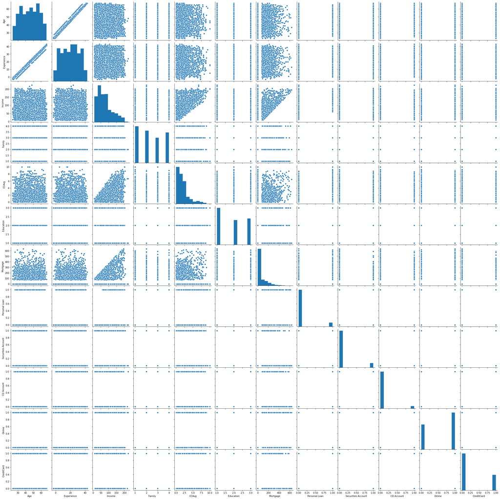

```python
## Visualising relationship using pariplot
sns.pairplot(bankloan);
```

Since Age and Experience show high correlation, we can drop experience as it would not impact the model

```python
bankloan.drop(columns=['Experience'], inplace=True)
```

```python
# Checking the remaining columns
bankloan.columns
```

```
Index(['Age', 'Income', 'Family', 'CCAvg', 'Education', 'Mortgage',
       'Personal Loan', 'Securities Account', 'CD Account', 'Online',
       'CreditCard'],
      dtype='object')
```

```
0    4478
1     522
Name: Securities Account, dtype: int64
```

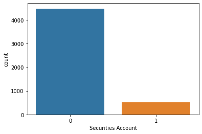

```
0    4698
1     302
Name: CD Account, dtype: int64
```

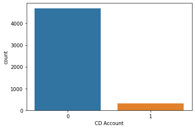

```
1    2984
0    2016
Name: Online, dtype: int64
```

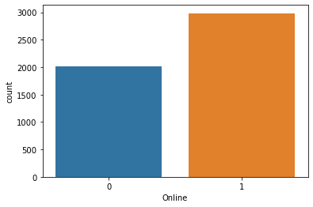

```
0    3530
1    1470
Name: CreditCard, dtype: int64
```

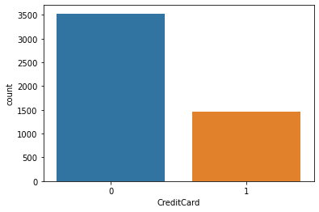

```python
# checking distribution for categorical attributes
for j in bankloan.columns[-4:]:
    print(bankloan[j].value_counts())
    sns.countplot(bankloan[j])
    plt.show();
```

```
1    1472
2    1296
4    1222
3    1010
Name: Family, dtype: int64
```

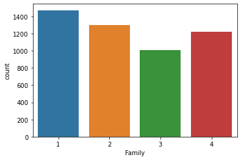

```
1    2096
3    1501
2    1403
Name: Education, dtype: int64
```

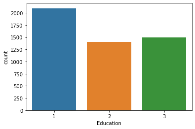

```python
for j in bankloan.columns[2:5:2]:
    print(bankloan[j].value_counts())
    sns.countplot(bankloan[j])
    plt.show();
```

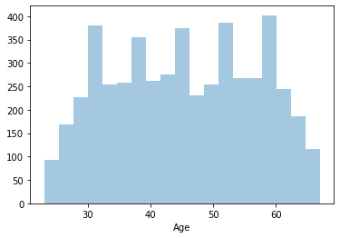

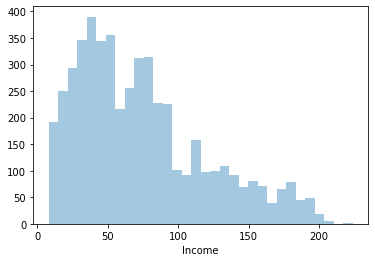

```python
# checking distribution for continuous atributes
for j in bankloan.columns[:2]:
    sns.distplot(bankloan[j], kde=False)
    plt.show();
```

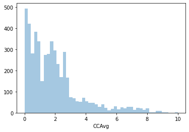

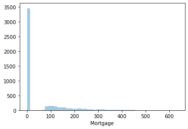

```python
for j in bankloan.columns[3:6:2]:
    sns.distplot(bankloan[j], kde=False)
    plt.show();
```

#### Based on the above plots, following can be observed:

1. ID - Being the priary key(identifier key), it has unique vaue for each record and hence is not required for model creation
2. Age - Continuous variable Age is uniformly distributed amongst the records. And from the pairplot it can be observed that number of people not taking personal loan is higher at age less than 30
3. Experience - Continuous variable Experience shows a high correlation with age, denoting a direct relation between Age of the person and experience of the person. It follows a similar distribution as age
4. Income - With around 50% correlation with Personal loan, Income shows a bell shaped curve skewed to the right. The number of customers with income higher than 100 decreases gradually.
5. ZIP code - Zip code denotes the address of the customer and is assumed to have no impact on the bank loan model.
6. Family - family size is distributed uniformly among 1,2,3 and 4 with 1 being highest at 1472 and 3 being lowest at 1010
7. CCAvg - Average Credit card spending shows a direct relation with income. The distribution is a bell shaped curve skewed to the right, similar to the income.
8. Education- The eduaction level is distributed uniformly with undergrad being approximately 40% while both graduate and Advanced being nearly 30% each.
9. Mortgage - Mortgage is distributed as follows: majority (approx 70%) of customers have zero mortgage while the 30% have mortgage ranging from 50 to 300 in a right skewed curve.
10. Securities Account - around 90% of customers do not have a securities account.
11. CD Account - Around 94% of customers do not have a CD account
12. Online - Number of customers using Internet banking facility is higher than customers who do not. Around 60% customers use online banking
13. Credit Card- Majority of customers(Around 70%) do not use bank credit card.

```
0    4520
1     480
Name: Personal Loan, dtype: int64
```

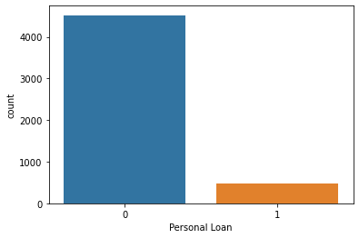

```python
# Target Column distribution
print(bankloan['Personal Loan'].value_counts())
sns.countplot(bankloan['Personal Loan'])
plt.show();
```

##### Following can be observed from Target column distribution

1. Majority of customers (over 90%) did not accept personal loan offered.
2. Based on pairplot and correlation metrix, personal loan shows greater than 30% correlation with the following attributes- Income(50%), CCAvg(36%),CD Account(31%)

```python
# Splitting data into train and test in ratio 7:3
# Personal loan as target variable
# Using train_test_split from sklearn.model_selection
X=bankloan.drop(columns=['Personal Loan'])
Y=bankloan['Personal Loan']
x_train, x_test, y_train, y_test = train_test_split(X, Y, test_size=0.3, random_state=1)
x_train.head()
```

|  | Age | Income | Family | CCAvg | Education | Mortgage | Securities Account | CD Account | Online | CreditCard |
| --- | --- | --- | --- | --- | --- | --- | --- | --- | --- | --- |
| 1334 | 47 | 35 | 2 | 1.3 | 1 | 0 | 0 | 0 | 1 | 0 |
| 4768 | 38 | 39 | 1 | 2.0 | 2 | 0 | 0 | 0 | 1 | 0 |
| 65 | 59 | 131 | 1 | 3.8 | 1 | 0 | 0 | 0 | 1 | 1 |
| 177 | 29 | 65 | 4 | 1.8 | 2 | 244 | 0 | 0 | 0 | 0 |
| 4489 | 39 | 21 | 3 | 0.2 | 2 | 0 | 0 | 0 | 1 | 0 |

```python
# Verifying the 70:30 split
(len(x_train)/len(bankloan.index))
```

```
0.7
```

```python
#Verifying the ratio of customers taking bankloan in train set is similar to that in original set
len(y_train[y_train[:]==1])/(len(y_train))
```

```
0.09457142857142857
```

```python
## defining function to fit the model and print Train accuracy score
def fitmodel(model,X,Y):
    print(model.fit(X,Y))
    print("Model Train accuracy score=",model.score(X,Y))

## Defining function to calculate Accuracy, F1, Precision and Recall scores
def scores(Yt,Yp):
    print("Model Test Accuracy score=",metrics.accuracy_score(Yt, Yp))
    print("Model F1 Score=",metrics.f1_score(Yt, Yp))
    print("Model Precision Score=",metrics.precision_score(Yt, Yp))
    print("Model Recall Score=",metrics.recall_score(Yt, Yp))

## Defining function to print confusion matrix and FP,FN values
def matrixprint(Yt,Yp):
    print("Confusion Matrix:")
    cm=metrics.confusion_matrix(Yt, Yp, labels=[1, 0])
    df_cm = pd.DataFrame(cm, index = [i for i in ["1","0"]],
                         columns = [i for i in ["Predict 1","Predict 0"]])
    print(df_cm,'\n')
    plt.figure(figsize = (7,5))
    sns.heatmap(df_cm, annot=True, fmt='g',square=True, cmap="Blues")
    plt.show();
    print("False Positive- Type 1 error- predicted will take loan but didn't-",df_cm.iloc[1][0])
    print("False Negative- Type 2 error- predicted will not take loan but taken-",df_cm.iloc[0][1])
```

### Using different Classification models

#### 1. Logistic Regression from sklearn.linear_model

```python
from sklearn.linear_model import LogisticRegression
# creating the model variable
lrmodel = LogisticRegression(solver="liblinear")
```

```python
# calling function fitmodel to fit train data on logistic regression model
fitmodel(lrmodel,x_train,y_train)
```

```
LogisticRegression(C=1.0, class_weight=None, dual=False, fit_intercept=True,
                   intercept_scaling=1, l1_ratio=None, max_iter=100,
                   multi_class='auto', n_jobs=None, penalty='l2',
                   random_state=None, solver='liblinear', tol=0.0001, verbose=0,
                   warm_start=False)
Model Train accuracy score= 0.9491428571428572
```

```python
# Predicting target column for test data using logistic regression model
y_test_predict_lr = lrmodel.predict(x_test)

# Calculating accuracy, F1 score, precision and recall for test data using Logistic regression model
scores(y_test,y_test_predict_lr)
```

```
Model Test Accuracy score= 0.9426666666666667
Model F1 Score= 0.6386554621848739
Model Precision Score= 0.8539325842696629
Model Recall Score= 0.5100671140939598
```

#### 2. Gaussian algorithm of Naive Bayes from sklearn.naive_bayes

```python
from sklearn.naive_bayes import GaussianNB

# creating the model variable
nbmodel = GaussianNB()
```

```python
# calling function fitmodel to fit train data on naive bayes gaussian model
fitmodel(nbmodel,x_train,y_train)
```

```
GaussianNB(priors=None, var_smoothing=1e-09)
Model Train accuracy score= 0.8894285714285715
```

```python
# Predicting target column for test data using naive bayes gaussian model
y_test_predict_nb = nbmodel.predict(x_test)
# Calculating accuracy, F1 score, precision and recall for test data using naive bayes gaussian model
scores(y_test,y_test_predict_nb)
```

```
Model Test Accuracy score= 0.8746666666666667
Model F1 Score= 0.4748603351955307
Model Precision Score= 0.40669856459330145
Model Recall Score= 0.5704697986577181
```

#### 3. K-Nearest Neighbor model from sklearn.neighbors

```python
## For K-NN we need to find the optimal value of n_neighbors, so testing scores for n=3,5,7
from sklearn.neighbors import KNeighborsClassifier

for i in range(7,2,-2):
    knnmodel = KNeighborsClassifier(n_neighbors=i , weights = 'distance')
    print("For n=",i)
    fitmodel(knnmodel,x_train,y_train)
    y_test_predict_knn = knnmodel.predict(x_test)
    scores(y_test,y_test_predict_knn)
```

```
For n= 7
KNeighborsClassifier(algorithm='auto', leaf_size=30, metric='minkowski',
                     metric_params=None, n_jobs=None, n_neighbors=7, p=2,
                     weights='distance')
Model Train accuracy score= 1.0
Model Test Accuracy score= 0.9053333333333333
Model F1 Score= 0.39316239316239315
Model Precision Score= 0.5411764705882353
Model Recall Score= 0.3087248322147651
For n= 5
KNeighborsClassifier(algorithm='auto', leaf_size=30, metric='minkowski',
                     metric_params=None, n_jobs=None, n_neighbors=5, p=2,
                     weights='distance')
Model Train accuracy score= 1.0
Model Test Accuracy score= 0.9073333333333333
Model F1 Score= 0.4326530612244898
Model Precision Score= 0.5520833333333334
Model Recall Score= 0.35570469798657717
For n= 3
KNeighborsClassifier(algorithm='auto', leaf_size=30, metric='minkowski',
                     metric_params=None, n_jobs=None, n_neighbors=3, p=2,
                     weights='distance')
Model Train accuracy score= 1.0
Model Test Accuracy score= 0.9113333333333333
Model F1 Score= 0.47011952191235057
Model Precision Score= 0.5784313725490197
Model Recall Score= 0.3959731543624161
```

```python
# Since all the scores increase as n decreases and are highest for n=3, setting n=3 for model.
# creating the model variable
knnmodel = KNeighborsClassifier(n_neighbors=3 , weights = 'distance')

# calling function fitmodel to fit train data on KNN model with n=3
fitmodel(knnmodel,x_train,y_train)

# Predicting target column for test data using KNN model
y_test_predict_knn = knnmodel.predict(x_test)

# Calculating accuracy, F1 score, precision and recall for test data using KNN model
scores(y_test,y_test_predict_knn)
```

```
KNeighborsClassifier(algorithm='auto', leaf_size=30, metric='minkowski',
                     metric_params=None, n_jobs=None, n_neighbors=3, p=2,
                     weights='distance')
Model Train accuracy score= 1.0
Model Test Accuracy score= 0.9113333333333333
Model F1 Score= 0.47011952191235057
Model Precision Score= 0.5784313725490197
Model Recall Score= 0.3959731543624161
```

#### 4. SVC algorithm of SVM model from sklearn

```python
from sklearn import svm

# creating the model variable
svmmodel = svm.SVC(gamma=0.025, C=3)
```

```python
# # calling function fitmodel to fit train data on SVM model
fitmodel(svmmodel,x_train,y_train)

# Predicting target column for test data using SVM model
y_test_predict_svm = svmmodel.predict(x_test)

# Calculating accuracy, F1 score, precision and recall for test data using SVM model
scores(y_test,y_test_predict_svm)
```

```
SVC(C=3, break_ties=False, cache_size=200, class_weight=None, coef0=0.0,
    decision_function_shape='ovr', degree=3, gamma=0.025, kernel='rbf',
    max_iter=-1, probability=False, random_state=None, shrinking=True,
    tol=0.001, verbose=False)
Model Train accuracy score= 0.988
Model Test Accuracy score= 0.9286666666666666
Model F1 Score= 0.4928909952606635
Model Precision Score= 0.8387096774193549
Model Recall Score= 0.348993288590604
```

### Printing Confusion metrix for all the above models:

#### 1. Logistic Regression Model

```
Confusion Matrix:
   Predict 1  Predict 0
1         76         73
0         13       1338
```

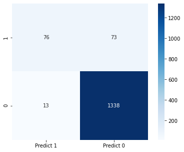

```
False Positive- Type 1 error- predicted will take loan but didn't- 13
False Negative- Type 2 error- predicted will not take loan but taken- 73
```

```python
matrixprint(y_test,y_test_predict_lr)
```

#### 2. Naive Bayes Model

```
Confusion Matrix:
   Predict 1  Predict 0
1         85         64
0        124       1227
```

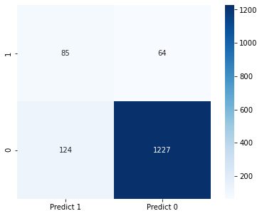

```
False Positive- Type 1 error- predicted will take loan but didn't- 124
False Negative- Type 2 error- predicted will not take loan but taken- 64
```

```python
matrixprint(y_test,y_test_predict_nb)
```

#### 3. K-NN Model

```
Confusion Matrix:
   Predict 1  Predict 0
1         59         90
0         43       1308
```

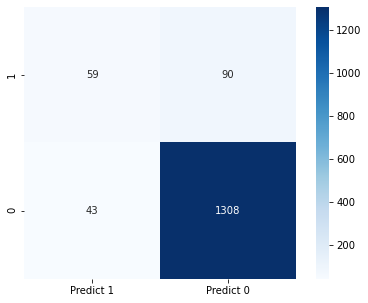

```
False Positive- Type 1 error- predicted will take loan but didn't- 43
False Negative- Type 2 error- predicted will not take loan but taken- 90
```

```python
matrixprint(y_test,y_test_predict_knn)
```

#### 4. SVM Model

```
Confusion Matrix:
   Predict 1  Predict 0
1         52         97
0         10       1341
```

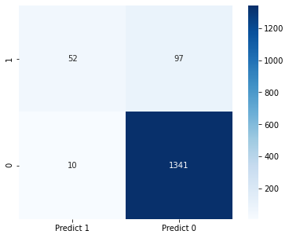

```
False Positive- Type 1 error- predicted will take loan but didn't- 10
False Negative- Type 2 error- predicted will not take loan but taken- 97
```

```python
matrixprint(y_test,y_test_predict_svm)
```

#### Best Model for the case:

Based on the various scores (Accuracy, Precision, Recall and F1) and considering the values of Type 1 and Type 2 error, Model - Logistic Regression can be considered the best fit model for the given case study.

The conclusion is based on the fact that for the given case of predicting customer taking bank loan, Type 1 error causes more harm in terms of loss of business(as the customer is predicted to take loan but does not), whilst Type 2 brings more personal loan taking customers to bank even though it reduces the overall accuracy and scores of model.

In terms of pure numbers, test accuracy for the models was approximately as follows:

Logistic Regression- 94.3% Naive Bayes-87.5% K-NN-91% SVM-93%

Now SVM had a huge difference between test and train accuracy, depicting slight overfitting, K-NN had a train accuracy of 100% showing overfit model, while in case of Logistic regression, both test and train accuracies are comparable, making it the best fit model.

Also, when other scores are considered, Logistic regression performs significantly better.

Finally, Only SVM and Logistic regression models are comparable in terms of False positive values. Even though FP score of SVM model is slightly lower than that of Logistic Regression, considering the above mentioned factors and the minimal difference between the FP values, the conclusion holds.

#### For the given case study, Logistic regression is the best fit model to predict the likelihood of a customer buying Personal Loan